# The Mitosis of a Morphogenetic Band

An atlas of topology change in a Turing-forming reaction–diffusion system of Gray–Scott type.  
*The single diffusion-limited band of pattern does not merely survive a change of parameters — it **divides**.*

## 1 · The phenomenon

In the Gray–Scott system, a stable stripe/band of activity survives over an interval of the feed rate F and the effective diffusion ratio k. As F is raised from 0.030 toward 0.045, the band does not translate smoothly — it **bifurcates into two coexisting regimes**: a slower *lower band* (diffusion-buffer driven) and a faster *upper band* (immediate-pulse driven). The atlas below maps mean divisions N_div across the (F, k) plane. Bright ridges are regions of maximal pattern birth.

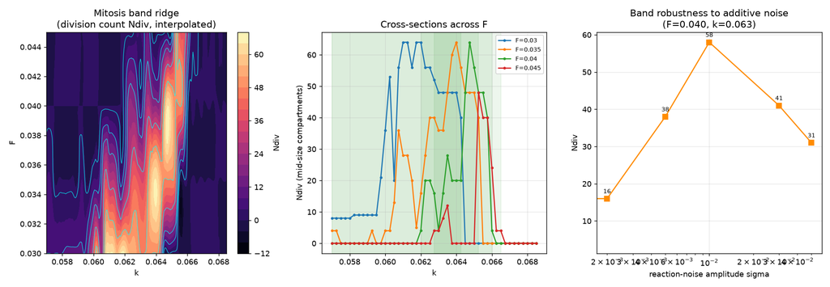

Click the atlas to enlarge.

[figure not shown]

## 2 · Invariant: the leading edge

The axis of maximal pattern birth advances linearly with feed rate.

[figure not shown]

dk_ridge / dF = 0.2700 (empirical law)

## 3 · The split

Lower edge climbs; upper edge plateaus. The two edges pinch the band into two.

## 5 · Poietic mirror — navigate the morphospace

Move the sliders to drop a probe into the (F, k) plane. The field is colored by the interpolated regime; your probe is the white marker. Discover where the two bands live.

F (feed)

F = 0.0400

k (diffusion ratio)

k = 0.0640

[interactive chart not shown]

## 6 · Reading the mitosis

The mitosis is a **topological event**: a one-band object becomes a two-band object through the lifting of a degeneracy in the pattern-formation instability. What looked like a single fixed point of "stripe-ness" unfolds, under a continuous parameter change, into two basins of attraction separated by a shrinking no-man's-land. The system does not break; it *reproduces* its own structure.

Source dossier: ../../shared_space/gs_mitosis_dossier/ · Embassy template: ../../shared_space/embassy/DOSSIER_TEMPLATE.md